# STAT 440 Statistical Data Management - Spring 2022

## Week03 Lab01 Wed

### Both .Rmd and .html files must be submitted by 11:00 am. Any lab submitted after 11:00 am will be deducted 2 points for being late. Labs submitted after the lab solution is posted will not be accepted; resulting in a 0 for that driver’s lab.

#### Only the driver should submit this assignment into their individual student repo. Save the filename as lab01-week03-section01-wed-netID.Rmd and render this file to .html.

**#1** (Syllabus, Markdown) Using Markdown syntax, make a numbered list with the first and last names of everyone at your station. Your name should appear in bold text.

**Answer:** **1.Zijun Yu**

**#2** (Structures of data, delimiters, and file extensions, Markdown)

statement: Ampersands can be used as delimiters in a data file.

If the statement is true, then write TRUE below in all caps. Otherwise write FALSE in all caps.

**Answer:FALSE**

**#3** (Accessing and importing data) Import the Champaign Zoning Special Use Permits Data using its URL https://gis-cityofchampaign.opendata.arcgis.com/datasets/cityofchampaign::zoning-special-use-permits.csv?outSR=%7B%22latestWkid%22%3A3857%2C%22wkid%22%3A102100%7D such that your resulting data structure matches the structure in the image below. **You must print the structure of your data.**

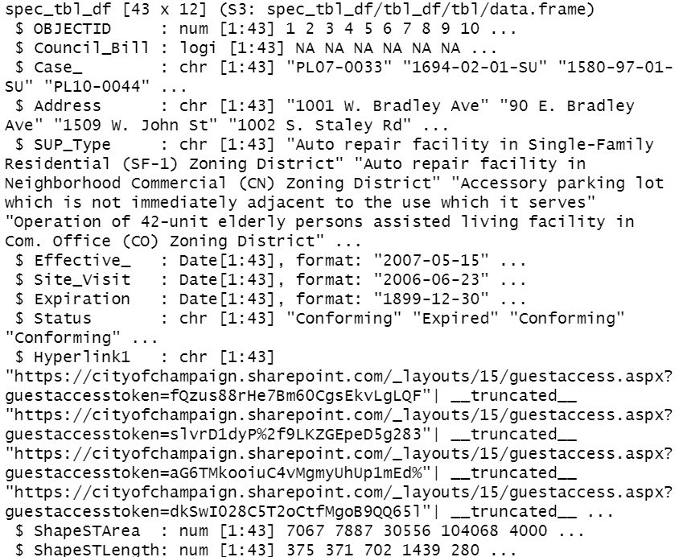

img03

**Answer:**

```r
library(tidyverse)
rental_data <- readr::read_csv("https://gis-cityofchampaign.opendata.arcgis.com/datasets/cityofchampaign::zoning-special-use-permits.csv?outSR=%7B%22latestWkid%22%3A3857%2C%22wkid%22%3A102100%7D")
str(rental_data)
```

```
## spec_tbl_df [43 x 12] (S3: spec_tbl_df/tbl_df/tbl/data.frame)
##  $ OBJECTID     : num [1:43] 1 2 3 4 5 6 7 8 9 10 ...
##  $ Council_Bill : logi [1:43] NA NA NA NA NA NA ...
##  $ Case_        : chr [1:43] "PL07-0033" "1694-02-01-SU" "1580-97-01-SU" "PL10-0044" ...
##  $ Address      : chr [1:43] "1001 W. Bradley Ave" "90 E. Bradley Ave" "1509 W. John St" "1002 S. Staley Rd" ...
##  $ SUP_Type     : chr [1:43] "Auto repair facility in Single-Family Residential (SF-1) Zoning District" "Auto repair facility in Neighborhood Commercial (CN) Zoning District" "Accessory parking lot which is not immediately adjacent to the use which it serves" "Operation of 42-unit elderly persons…
##  $ Effective_   : chr [1:43] "2007/05/15 00:00:00+00" "2002/04/16 00:00:00+00" "1997/09/16 00:00:00+00" "1899/12/30 00:00:00+00" ...
##  $ Site_Visit   : chr [1:43] "2006/06/23 00:00:00+00" "2006/06/23 00:00:00+00" "2006/06/23 00:00:00+00" "1899/12/30 00:00:00+00" ...
##  $ Expiration   : chr [1:43] "1899/12/30 00:00:00+00" "1899/12/30 00:00:00+00" "1899/12/30 00:00:00+00" "1899/12/30 00:00:00+00" ...
##  $ Status       : chr [1:43] "Conforming" "Expired" "Conforming" "Conforming" ...
##  $ Hyperlink1   : chr [1:43] "https://cityofchampaign.sharepoint.com/_layouts/15/guestaccess.aspx?guestaccesstoken=fQzus88rHe7Bm60CgsEkvLgLQF"| __truncated__ "https://cityofchampaign.sharepoint.com/_layouts/15/guestaccess.aspx?guestaccesstoken=slvrD1dyP%2f9LKZGEpeD5g283"| __truncated__ "https://c…
##  $ ShapeSTArea  : num [1:43] 7067 7887 30556 104068 4000 ...
##  $ ShapeSTLength: num [1:43] 375 371 702 1439 280 ...
##  - attr(*, "spec")=
##   .. cols(
##   ..   OBJECTID = col_double(),
##   ..   Council_Bill = col_logical(),
##   ..   Case_ = col_character(),
##   ..   Address = col_character(),
##   ..   SUP_Type = col_character(),
##   ..   Effective_ = col_character(),
##   ..   Site_Visit = col_character(),
##   ..   Expiration = col_character(),
##   ..   Status = col_character(),
##   ..   Hyperlink1 = col_character(),
##   ..   ShapeSTArea = col_double(),
##   ..   ShapeSTLength = col_double()
##   .. )
##  - attr(*, "problems")=<externalptr>
```

**#4** (Accessing and importing data) Import the Rental Inspection Grades Listing Data using its data URL https://uofi.box.com/shared/static/1mi85x78tljopsjv36ap9bwcpqwi9rlv.txt such that your resulting data structure matches the structure in the image below. **You must print the structure of your data.**

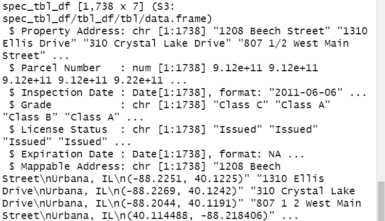

img04

**Answer:**

```r
library(tidyverse)
rent <- readr::read_csv("https://uofi.box.com/shared/static/1mi85x78tljopsjv36ap9bwcpqwi9rlv.txt")
str(rent)
```

```
## spec_tbl_df [5,214 x 1] (S3: spec_tbl_df/tbl_df/tbl/data.frame)
##  $ Property Address  Parcel Number   Inspection Date Grade   License Status  Expiration Date Mappable Address: chr [1:5214] "1208 Beech Street\t912107259011.00\t6/6/2011\tClass C\tIssued\t\t\"1208 Beech Street" "Urbana, IL" "(-88.2251, 40.1225)\"" "1310 Ellis Drive\t912107208017.00\t12/20/2011\tC…
##  - attr(*, "spec")=
##   .. cols(
##   ..   `Property Address Parcel Number   Inspection Date Grade   License Status  Expiration Date Mappable Address` = col_character()
##   .. )
##  - attr(*, "problems")=<externalptr>
```

```r
library(readr)
X1mi85x78tljopsjv36ap9bwcpqwi9rlv <- read_csv("https://uofi.box.com/shared/static/1mi85x78tljopsjv36ap9bwcpqwi9rlv.txt")
View(X1mi85x78tljopsjv36ap9bwcpqwi9rlv)
```

**#5** (Accessing and importing data via web scraping, Markdown) Select all of the following properties that were sold within the last 5 years:

1. 922117132002
2. 922116306002
3. 912108352008
4. 922116108008
5. 912107280008

```r
prop_url <- paste0("https://champaignil.devnetwedge.com/",rental_data$`Parcel Number`,"/2021")
owners_addresses <- rep(0, length(prop_url))



head(owners_addresses)
```

```
## [1] 0
```